# Small substitution drivers

Working with the gene-centric dndscv approach and the gene-agnostic ActiveDriverWGS approach, we explore small substitution (snv to in/del size) drivers.

## Prepare data

```r
#BiocManager::install(c('BSgenome.Hsapiens.UCSC.hg19', 'BSgenome.Hsapiens.UCSC.hg38', 'BSgenome.Mmusculus.UCSC.mm9', 'BSgenome.Mmusculus.UCSC.mm10'))
#devtools::install_github('https://github.com/reimandlab/ActiveDriverWGSR')
#devtools::install_github("im3sanger/dndscv")

suppressWarnings(

suppressPackageStartupMessages({
  library(data.table)
  library(tidyr)
  library(dplyr)
  library(GenomicRanges)
  #library(CNTools)
  library(ActiveDriverWGS)
  library(dndscv)
  library(ggplot2)
  library(ggrepel)
})
)

packageVersion('ActiveDriverWGS')
```

```
## [1] '1.2.1'
```

```r
packageVersion('dndscv')
```

```
## [1] '0.0.1.0'
```

```r
'%ni%' <- function(x,y)!('%in%'(x,y))

code.dir = '~/Documents/scripts/github/btc-ccs/'
data.dir = '~/Documents/scripts/github/btc-ccs-data/'

source(paste0(code.dir,"/bin/driver_functions.R"))
source( file.path(data.dir, "paths.R"))
cluster.dir = file.path(cluster.dir, 'more.data')


##define genes (using dnds Granges)
dndscv_reference_data_path <- file.path(data.dir,'/source_data/RefCDS_human_GRCh38_GencodeV18_recommended.rda')
load(file=dndscv_reference_data_path)

candidate_gene_exons <- data.frame(chr=paste0('chr',seqnames(gr_genes)),
                           start=start(gr_genes),
                           end=end(gr_genes),
                           id=gr_genes$names)

##writes to file
make_vcfs=F
if(make_vcfs){
  ## define sample set ##

  sample.list <- fread(file.path(data.dir,'/source_data/sample.list.txt'), header=F)

  collate_barebones_vcf_write(sample.list,
                              inpath=cluster.dir,
                              outpath=file.path(data.dir,'/results/'),
                              variant_types = c("indel","snv"))
}


all_mutations <- read.delim(file.path(data.dir,"/results/all_mutations.txt"))
length(unique(all_mutations$patient))
```

```
## [1] 180
```

```r
all_mutations <- all_mutations %>% arrange(patient,chr,pos1,pos2)

#removes scaffolds without candidate genes
all_mutations <- all_mutations[all_mutations$chr %in% unique(candidate_gene_exons$chr),]
#also a check that the candidate annotation and mutation annotation match

dndscv_muts <- all_mutations[,c("patient", "chr", "pos1", "ref", "alt")]
names(dndscv_muts) <- c("sampleID", "chr", "pos", "ref", "mut")
dndscv_muts$chr <- gsub(pattern = 'chr', replacement = '', dndscv_muts$chr)
```

## run driver analyses

activedriver takes up to 12 hours so we don’t run that every time.

```r
get_drivers = F
if(get_drivers){

  result <- tryCatch({
    dndsout = dndscv(dndscv_muts, refdb =  dndscv_reference_data_path, outp = 3, cv = NULL)
  }, error = function(e) {
    message("Error: ", e)
    NULL
  })


  dndsout.annotmuts <- dndsout$annotmuts

  write.table(
    dndsout$sel_cv,
    file = paste0(data.dir, "/results/sel_cv.txt"),
    row.names = FALSE, quote = FALSE, sep = "\t"
  )

  write.table(
    dndsout$annotmuts,
    file = paste0(data.dir, "/results/dnds_annotation.txt"),
    row.names = FALSE, quote = FALSE, sep = "\t"
  )

  active_driver_results = ActiveDriverWGS(mutations = all_mutations,
                                          elements = candidate_gene_exons,
                                          ref_genome = 'hg38')

  write.table(
    active_driver_results,
    file = paste0(data.dir, "/results/active_driver_results.txt"),
    row.names = FALSE, quote = FALSE, sep = "\t"
  )

  #### promoters ####
  regulatory_features <- fread(file.path(data.dir,'source_data/homo_sapiens.GRCh38.Regulatory_Build.regulatory_features.20231016.gff'))
  regulatory_features$V1 <- paste0('chr',regulatory_features$V1)
  promoters <- regulatory_features[regulatory_features$V3 == 'promoter',]

  #https://genome-euro.ucsc.edu/cgi-bin/hgTables?db=hg38&hgta_group=hub_669493&hgta_track=hub_669493_epdnew&hgta_table=hub_669493_epdnew6&hgta_doSchema=describe+table+schema
  #EPD based on experimental and bioinformatics TSS, so likely more strict
  EPD_promoters <- fread(file.path(data.dir,'source_data/Hs_EPDnew_006_hg38.bed'))

  promoters$epd <- NA
  for(this.epd.promoter in EPD_promoters$V4){

    this.chr <- EPD_promoters$V1[EPD_promoters$V4 == this.epd.promoter]
    this.start <- EPD_promoters$V2[EPD_promoters$V4 == this.epd.promoter]
    this.end <- EPD_promoters$V3[EPD_promoters$V4 == this.epd.promoter]

    this.ens.match <- promoters$epd[(promoters$V4 - 20) <= this.start & this.end  <= (promoters$V5 + 20) & promoters$V1 == this.chr ]
    if(length(this.ens.match) == 0 ){
      cat(this.epd.promoter,' not found\n')
    } else if(is.na(this.ens.match)){
      promoters$epd[promoters$V4 <= this.start & this.end  <= promoters$V5 & promoters$V1 == this.chr ] <- this.epd.promoter
    } else {
      promoters$epd[promoters$V4 <= this.start & this.end  <= promoters$V5 & promoters$V1 == this.chr ] <- paste(this.ens.match, this.epd.promoter, sep = '; ')

    }

  }

  promoters <- promoters[!is.na(promoters$epd),]

  candidate_promoters <- data.frame(chr=promoters$V1,
                                    start=promoters$V4,
                                    end=promoters$V5,
                                    id=promoters$epd)


  all_mutations <- fread(file.path(data.dir,"/results/all_mutations.txt"))
  all_mutations <- all_mutations[all_mutations$chr %in% unique(candidate_promoters$chr),]

  active_driver_results.promoters = ActiveDriverWGS(mutations = all_mutations,
                                                    elements = candidate_promoters,
                                                    ref_genome = 'hg38')

  write.table(
    active_driver_results.promoters,
    file = file.path(data.dir,"/results/active_driver_results.promoters.txt"),
    row.names = FALSE, quote = FALSE, sep = "\t"
  )

}
```

## review results

Let’s compare drivers discovered by the two methods. We manually review cases with mutations in new drivers (eg PTH2) using IGV; spoiler alert: they are artefacts.

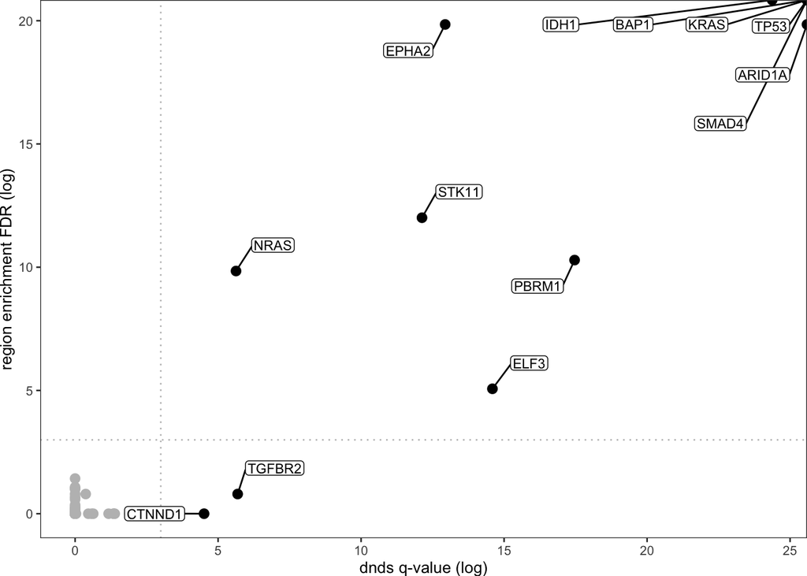

```r
active_driver_results <- fread(paste0(data.dir, "/results/active_driver_results.txt"))
active_drivers <- active_driver_results$id[active_driver_results$fdr_element < 1 & active_driver_results$element_muts_obs > 4]

sel_cv <- fread(paste0(data.dir, "/results/sel_cv.txt"))
dnds_annotation <- fread(paste0(data.dir, "/results/dnds_annotation.txt"))

all_genes <- fread(file.path(data.dir,'/source_data/fgs.txt'))
gene_set <- all_genes[all_genes$biotype=="protein_coding" & all_genes$Length >= 500,]
#cancerGeneList <- fread(file.path(data.dir,'/source_data/cancerGeneList.tsv'))


positioned_drivers <- left_join( active_driver_results, all_genes, by=c("id"="gene_name"))
positioned_drivers_dnds <- full_join( positioned_drivers, sel_cv, by=c("id"="gene_name"))

positioned_drivers_dnds$chr_fac <- factor(gsub("chr","",positioned_drivers_dnds$Chr), levels=c(1:22,'X'))
positioned_drivers_dnds <- positioned_drivers_dnds %>% filter(!is.na(chr_fac))

positioned_drivers_dnds$fdr_element_sigfig <- signif(positioned_drivers_dnds$fdr_element, 2)
positioned_drivers_dnds$qglobal_cv_sigfig <- signif(positioned_drivers_dnds$qglobal_cv, 2)

## filter False Positives
#PTH2: low VAF, in repeat region, same spot
#USP8: unsure, complex recurrent mutation: always same two in-phase mutations ~8 bp apart
positioned_drivers_dnds <- positioned_drivers_dnds %>% filter(id %ni% c('PTH2','USP8'))

sig_id <- positioned_drivers_dnds$id[positioned_drivers_dnds$fdr_element_sigfig < 0.05 | positioned_drivers_dnds$qglobal_cv_sigfig < 0.05]

positioned_drivers_dnds.plot <- positioned_drivers_dnds
positioned_drivers_dnds.plot$fdr_element_sigfig[-log(positioned_drivers_dnds.plot$fdr_element_sigfig) > 30] <- 0

#subsampling rows in bottom left corner of dots that would just stack, for file size
keep_rows <- positioned_drivers_dnds.plot[positioned_drivers_dnds.plot$fdr_element_sigfig < 1 |positioned_drivers_dnds.plot$qglobal_cv_sigfig < 1 ]
sample_rows <- positioned_drivers_dnds.plot[positioned_drivers_dnds.plot$fdr_element_sigfig == 1, ]
sampled_subset <- sample_rows[sample(nrow(sample_rows), 20), ]

positioned_drivers_dnds.plot <- rbind.data.frame(keep_rows, sampled_subset)

drivers.pvalues.plot <-
ggplot(positioned_drivers_dnds.plot, aes(y=-log(fdr_element_sigfig), x=-log(qglobal_cv_sigfig))) +

  geom_vline(xintercept = -log(0.05), color='grey', linetype='dotted')+
  geom_hline(yintercept = -log(0.05), color='grey', linetype='dotted')+

  geom_point(size=2.5, color='grey') +
  geom_point(size=2.5, data = ~ subset(., id %in% sig_id)) +
  geom_label_repel(aes(label=id),
                   data = ~ subset(., id %in% sig_id), size=3, max.overlaps =20,
                   box.padding = 0.75, force = 0.1, label.padding = 0.1,
                   max.time = 3) +

  theme_bw(base_size=10) +
  theme(
    plot.margin = unit(c(0, 0, 0, 0), "mm"),
    panel.background = element_blank(),
    plot.background = element_blank(),
    panel.grid.major = element_blank(),
    panel.grid.minor = element_blank()
  ) +

  labs(y="region enrichment FDR (log)",x="dnds q-value (log)")

drivers.pvalues.plot
```

```r
ggsave(file.path(data.dir, "/results/fig/FIG4A.drivers.pvalues.svg"), plot =
       drivers.pvalues.plot
, device = "svg",width = 75, height = 75 , units='mm', dpi=72 )
```

## analyze drivers by subtype

We also compared global signals of selection between the subtypes - although these results were tantalizing, we found the conclusion were extremely inconsistent and the signal could completely flip just by the addition/removal of a couple samples - so this was ultimately removed from the final manuscript.

```r
predicted.w.score <- fread(file.path(data.dir,'/results/all.eCCS.txt') )

cms.drivers.pvalues.plot <- compare_ccs_dnds(dndscv_muts, predicted.w.score, 'all')
```

```
## [1] Loading the environment...
```

```
## [2] Annotating the mutations...
```

```
##     Note: 5 mutations removed for exceeding the limit of mutations per gene per sample (see the max_muts_per_gene_per_sample argument in dndscv)
```

```
## [3] Estimating global rates...
```

```
## [4] Running dNdSloc...
```

```
## [5] Running dNdScv...
```

```
##     Regression model for substitutions: no covariates were used (theta = 4.38).
```

```
##     Regression model for indels (theta = 0.984)
```

```
## [1] Loading the environment...
```

```
## [2] Annotating the mutations...
```

```
##     Note: 7 mutations removed for exceeding the limit of mutations per gene per sample (see the max_muts_per_gene_per_sample argument in dndscv)
```

```
##     74% ...
```

```
## [3] Estimating global rates...
```

```
## [4] Running dNdSloc...
```

```
## [5] Running dNdScv...
```

```
##     Regression model for substitutions: no covariates were used (theta = 4.6).
```

```
##     Regression model for indels (theta = 1.24)
```

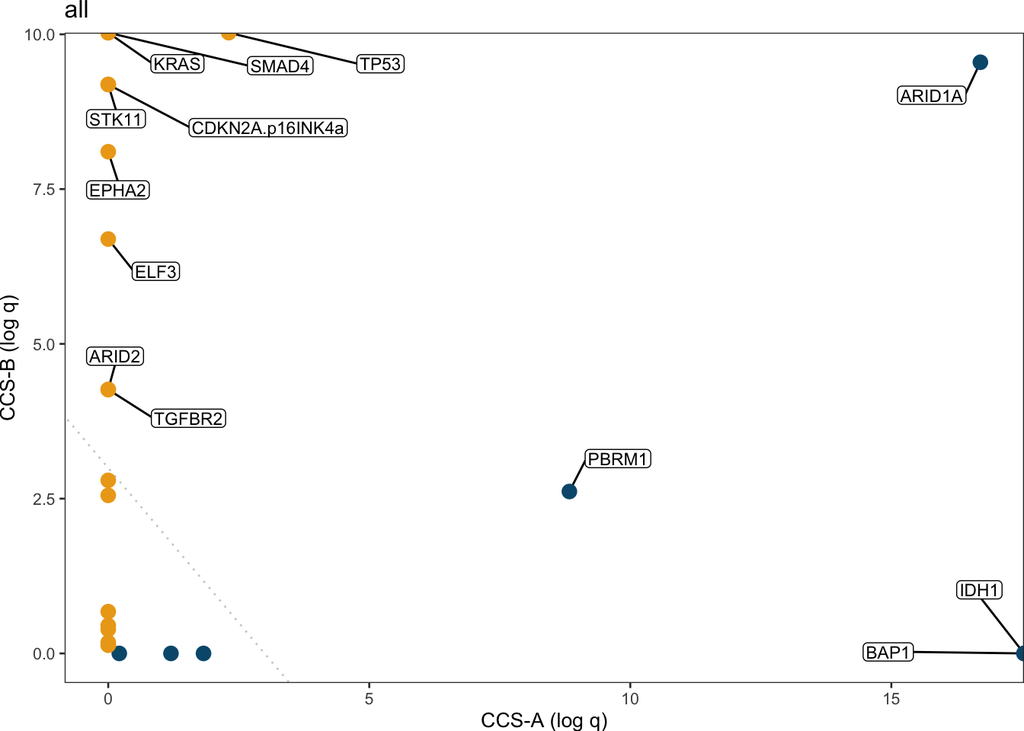

```r
cms.drivers.pvalues.plot
```

```r
ggsave(paste0(data.dir, "/results/fig/FIGS4b.ccs.drivers.pvalues.svg"), plot =
  cms.drivers.pvalues.plot
, device = "svg",width = 65, height = 65 , units='mm', dpi=72 )

clinic.sample.info <- fread(file.path(data.dir,"/results/samples.info.txt"), header=T)
primaries <- clinic.sample.info$Sample[clinic.sample.info$Sample_Progression == 'Primary']
naive <- clinic.sample.info$Sample[clinic.sample.info$tissue_before_chemo == T]

ccs.dnds.primaries.plot <-
  compare_ccs_dnds(dndscv_muts %>% filter(sampleID %in% primaries),
                 predicted.w.score,
                 'primaries')
```

```
## [1] Loading the environment...
```

```
## [2] Annotating the mutations...
```

```
##     Note: 5 mutations removed for exceeding the limit of mutations per gene per sample (see the max_muts_per_gene_per_sample argument in dndscv)
```

```
## [3] Estimating global rates...
```

```
## [4] Running dNdSloc...
```

```
## [5] Running dNdScv...
```

```
##     Regression model for substitutions: no covariates were used (theta = 4.47).
```

```
##     Regression model for indels (theta = 1.3)
```

```
## [1] Loading the environment...
```

```
## [2] Annotating the mutations...
```

```
##     Note: 4 mutations removed for exceeding the limit of mutations per gene per sample (see the max_muts_per_gene_per_sample argument in dndscv)
```

```
## [3] Estimating global rates...
```

```
## [4] Running dNdSloc...
```

```
## [5] Running dNdScv...
```

```
##     Regression model for substitutions: no covariates were used (theta = 4.58).
```

```
##     Regression model for indels (theta = 0.928)
```

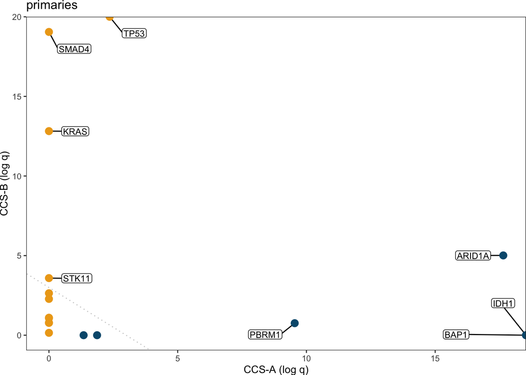

```r
ccs.dnds.primaries.plot
```

```r
ggsave(paste0(data.dir, "/results/fig/FIGS4b.ccs.drivers.primaries.svg"), plot =
  ccs.dnds.primaries.plot
, device = "svg",width = 65, height = 65 , units='mm', dpi=72 )

ccs.dnds.naive.plot <-
  compare_ccs_dnds(dndscv_muts %>% filter(sampleID %in% naive),
                 predicted.w.score,
                 'treatment naive')
```

```
## [1] Loading the environment...
```

```
## [2] Annotating the mutations...
```

```
## [3] Estimating global rates...
```

```
## [4] Running dNdSloc...
```

```
## [5] Running dNdScv...
```

```
##     Regression model for substitutions: no covariates were used (theta = 33).
```

```
##     Regression model for indels (theta = 0.589)
```

```
## [1] Loading the environment...
```

```
## [2] Annotating the mutations...
```

```
##     Note: 5 mutations removed for exceeding the limit of mutations per gene per sample (see the max_muts_per_gene_per_sample argument in dndscv)
```

```
## [3] Estimating global rates...
```

```
## [4] Running dNdSloc...
```

```
## [5] Running dNdScv...
```

```
##     Regression model for substitutions: no covariates were used (theta = 4.17).
```

```
##     Regression model for indels (theta = 1.82)
```

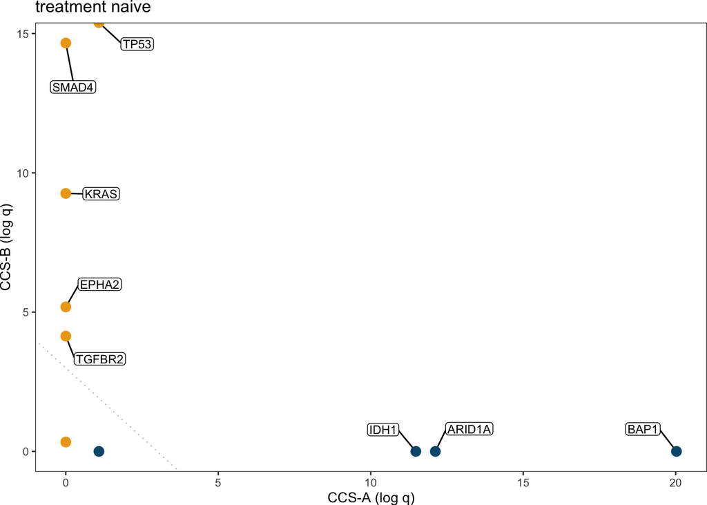

```r
ccs.dnds.naive.plot
```

```r
ggsave(paste0(data.dir, "/results/fig/FIGS4b.ccs.drivers.naive.svg"), plot =
  ccs.dnds.naive.plot
, device = "svg",width = 65, height = 65 , units='mm', dpi=72 )
```

## test loss-of-heterozygosity

I think this is a new type of analysis. What we wanted to do originally was rescue tumor suppressor genes that were just under the FDR threshold by showing that there was more LOH at those sites than expected by chance. We actually didn’t end up recovering anything this way, but we found interesting results nonetheless.

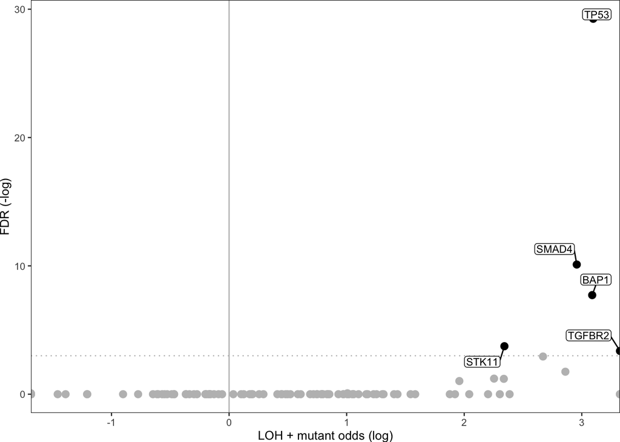

```r
gene_set <- fread(file.path(data.dir,'/source_data/fgs.txt'))
gene_set$Chr <- paste0('chr', gene_set$Chr)

genebed <- gene_set
genebed <- genebed %>% filter(biotype=="protein_coding" & Length >= 500)
genebed <- genebed %>% dplyr::select(Chr, Start,   End,ensid, gene_name)
names(genebed) <- c('chrom',    'start',    'end',  'geneid',   'genename')

dnds_annotation <- fread(paste0(data.dir, "/results/dnds_annotation.txt"))

get_loh= F
if(get_loh){


  all.cnv <- fread(file.path(cluster.dir, 'all.cnv.txt'))
  length(unique(all.cnv$sampleID))

  all.cnv$toy.marker <- 1
  all.cn <- all.cnv %>% dplyr::select(sampleID, chrom,start.pos,end.pos,toy.marker, imean)
  names(all.cn) <- c('ID','chrom','loc.start','loc.end','num.mark','seg.mean')

  all.cnv <- all.cnv %>% dplyr::select(sampleID, chrom,start.pos,end.pos,toy.marker, labels) %>% filter(!is.na(labels))
  names(all.cnv) <- c('ID','chrom','loc.start','loc.end','num.mark','seg.mean')

  allele.cn.seg <- CNSeg(all.cnv)
  allele.cn.gene <- getRS(allele.cn.seg, by="gene", imput=FALSE, XY=FALSE, geneMap=genebed, what="min")
  gene.allele <- rs(allele.cn.gene)

  these.genes = intersect(unique(dnds_annotation$gene), gene.allele$genename)

  rescue_id <- positioned_drivers_dnds$id[positioned_drivers_dnds$element_enriched == T & positioned_drivers_dnds$pglobal_cv < 0.05]

  these.genes = intersect(these.genes, rescue_id)


  first.row = T
  for(this.gene in these.genes){

    this.cn <- gene.allele[gene.allele$genename == this.gene,]
    if(nrow(this.cn) == 1){

      this.cn <- as.data.frame(t(this.cn[,-c(1:5)]))
      names(this.cn) <- 'cn'

      these.alleles <- separate(this.cn, col = 'cn', into = c('a','b'), sep = '\\.')
      these.alleles$loh <- F
      these.alleles$loh[these.alleles$a == 0 | these.alleles$b == 0  ] <- T

      this.annot <- dnds_annotation[dnds_annotation$gene == this.gene,]
      these.alleles$hit <- F
      these.alleles$hit[row.names(these.alleles) %in% this.annot$sampleID] <- T

      this.table <- these.alleles %>% group_by(loh,hit) %>% tally() %>% reshape2::dcast(formula = loh ~ hit, value.var = 'n', fill = 0  )

      if(nrow(this.table) * ncol(this.table) == 6){

        fish.res <- fisher.test(this.table[,-1], conf.int = T)

        tmp.tbl <- cbind.data.frame('gene'=this.gene,
                                    'loh.pvalue'=fish.res$p.value,
                                    'loh.TTn'= this.table[2,3],
                                    'loh.LOR'=log(fish.res$estimate)
        )

        if(first.row){
          loh.hit.table<- tmp.tbl
          first.row =F
        } else {
          loh.hit.table<- rbind.data.frame(loh.hit.table, tmp.tbl)

        }
      }
    } else {
      message('two rows with the gene name: ',this.gene)
    }

  }
  loh.hit.table <- loh.hit.table %>% arrange( loh.pvalue)
  write.table(
    loh.hit.table,
    file = file.path(data.dir, "/results/loh.p.txt"),
    row.names = FALSE, quote = FALSE, sep = "\t"
  )

}

loh.hit.table <- fread(file.path(data.dir, "/results/loh.p.txt"))

loh.hit.table$fdr <- p.adjust(loh.hit.table$loh.pvalue, method='fdr')
loh_sig_id <- loh.hit.table$gene[loh.hit.table$fdr < 0.05 ]

drivers.loh.plot <-
ggplot(loh.hit.table, aes(x=loh.LOR, y= -log(fdr))) +

  geom_hline(yintercept = -log(0.05), color='grey', linetype='dotted')+

  geom_vline(xintercept = 0, color='grey')+
  geom_point(size=2.5, color='grey') +
  geom_point(size=2.5, data = ~ subset(., gene %in% loh_sig_id)) +
  geom_label_repel(aes(label=gene),  data = ~ subset(., gene %in% loh_sig_id), size=3,
                   box.padding = 0.5, force = 1, max.time = 3,  label.padding = 0.1, min.segment.length = 0) +


  theme_bw(base_size=10) +

  theme(
    plot.margin = unit(c(0, 0, 0, 0), "mm"),
    panel.background = element_blank(),
    plot.background = element_blank(),
    panel.grid.major = element_blank(),
    panel.grid.minor = element_blank()
  ) + labs(x='LOH + mutant odds (log)', y='FDR (-log)')

drivers.loh.plot
```

```r
ggsave(paste0(data.dir, "/results/fig/FIGS4d.drivers.loh.svg"), plot =
         drivers.loh.plot
, device = "svg",width = 60, height = 75 , units='mm' , dpi=72 )
```

## combine LOH and dnds for table

```r
smm.drivrs.analysis <- full_join(positioned_drivers_dnds, loh.hit.table, by=c('id'='gene'))

positioned_drivers_only <- smm.drivrs.analysis[smm.drivrs.analysis$fdr_element_sigfig < 0.05  |

                                                 smm.drivrs.analysis$qglobal_cv_sigfig < 0.05 ,]


positioned_drivers_only$n_mut <- positioned_drivers_only$n_syn + positioned_drivers_only$n_mis + positioned_drivers_only$n_non +
  positioned_drivers_only$n_spl + positioned_drivers_only$n_ind

positioned_drivers_only$loh.fdr <- p.adjust(positioned_drivers_only$loh.pvalue, method = "BH")


positioned_drivers_table <- positioned_drivers_only %>%
  dplyr::select(id, chr_fac, n_mut, fdr_element_sigfig,  qglobal_cv_sigfig, loh.fdr, loh.TTn) %>% arrange(desc(n_mut))


format_sigfig <- function(x, sigfig = 2) {
  if (is.numeric(x)) {
    sapply(x, function(val) {
      if (is.na(val)) return(NA)
      if (abs(val) < 0.0001 && val != 0) {
        format(signif(val, sigfig), scientific = TRUE)
      } else {
        format(signif(val, sigfig), scientific = FALSE, trim = TRUE)
      }
    })
  } else {
    x
  }
}


positioned_drivers_table[] <- lapply(positioned_drivers_table, format_sigfig)

write.table(
  positioned_drivers_table,
  file = paste0(data.dir, "/results/TableS3.positioned_drivers_table.txt"),
  row.names = FALSE, quote = FALSE, sep = "\t"
)

positioned_drivers_table
```

```
##         id chr_fac  n_mut fdr_element_sigfig qglobal_cv_sigfig loh.fdr loh.TTn
##     <char>  <fctr> <char>             <char>            <char>  <char>  <char>
##  1:   TP53      17     62            3.5e-72                 0 1.3e-14      53
##  2: ARID1A       1     33            2.4e-09                 0   0.099      24
##  3:   BAP1       3     31            1.6e-27                 0 2.8e-05      29
##  4:  SMAD4      18     24            7.5e-16                 0 2.6e-06      19
##  5:   KRAS      12     21            2.4e-26                 0       1       2
##  6:   IDH1       2     19            1.1e-14           2.6e-11    0.72       0
##  7:  EPHA2       1     19            2.4e-09           2.4e-06     0.5      14
##  8:  PBRM1       3     17            3.4e-05           2.6e-08   0.025      15
##  9:  STK11      19     12            6.1e-06           5.4e-06  0.0015       8
## 10:   ELF3       1     11             0.0063           4.6e-07       1       1
## 11: TGFBR2       3      9               0.45            0.0034  0.0022      11
## 12: CTNND1      11      8                  1             0.011    0.72       0
## 13:   NRAS       1      7            5.3e-05            0.0036     0.5       0
```